# Course_project_01

as

2023-10-24

## First part of the assingment is loading the data

```r
data <- read.csv("activity.csv")
```

Next, I need to calculate the total number of steps taken each day, ignoring the missing values. I will do this by grouping the data by column “date”. Finally, a plot shows a total number of steps taken for each day.

```r
library(dplyr)
```

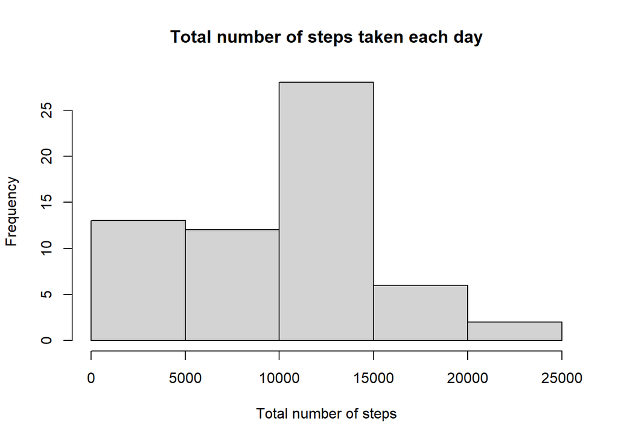

```r
grouped <- data %>%
  group_by(date) %>%
  summarise(total = sum(steps, na.rm = TRUE) )

grouped$date <- as.Date(grouped$date, "%Y-%m-%d")
hist(grouped$total,
        main = "Total number of steps taken each day",
        xlab = "Total number of steps", ylab = "Frequency")
```

The mean value of the total number of steps taken per day is 9354.2295082, while the median is equal to 10395.

The second part is looking at the specific time interval during the day. This means that I need to group the data by “interval” column. After grouping the data, I need to calculate the average of steps taken at that interval, for all days in question.

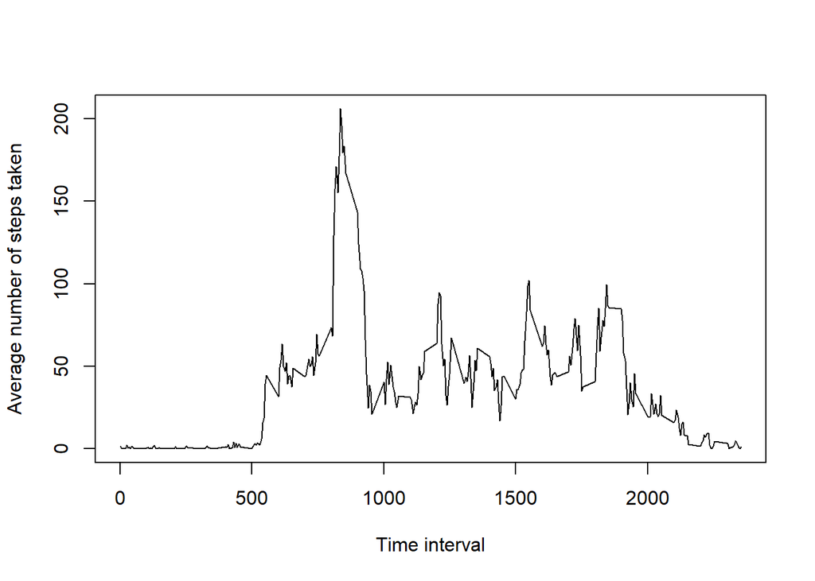

```r
interval_grouped <- data %>%
  group_by(interval) %>%
  summarise(average= mean(steps, na.rm = TRUE))
index <- which.max(interval_grouped$average)
plot(interval_grouped, type = "l",
     xlab = "Time interval", ylab = "Average number of steps taken")
```

The maximum average number of steps is taken at 835, meaning 8:35.

```r
library(tidyr)
mean_value = mean(grouped$total)/(length(grouped$total)**2)
new_dataset <- data.frame(data)
new_dataset$steps[is.na(new_dataset$steps)] <- mean_value

new_dataset <- new_dataset %>%
  group_by(date) %>%
  summarise(total = sum(steps))

head(new_dataset)
```

```
## # A tibble: 6 × 2
##   date        total
##   <chr>       <dbl>
## 1 2012-10-01   724.
## 2 2012-10-02   126
## 3 2012-10-03 11352
## 4 2012-10-04 12116
## 5 2012-10-05 13294
## 6 2012-10-06 15420
```

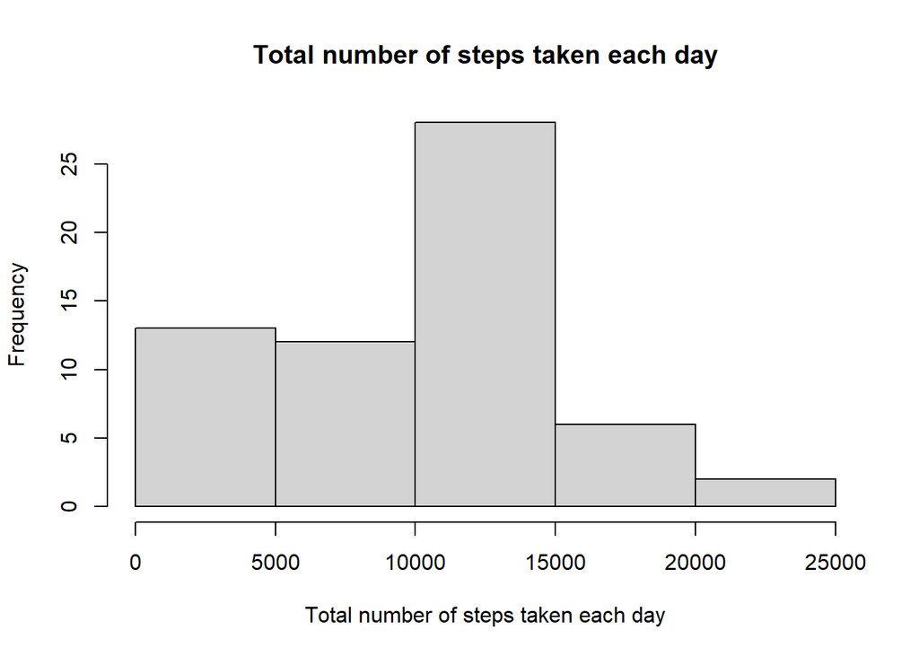

```r
hist(new_dataset$total,
        main = "Total number of steps taken each day",
        xlab = "Total number of steps taken each day", ylab = "Frequency")
```

The mean value of the total number of steps taken per day is 9449.1808248, while the median is equal to 1.0395^{4}. The mean value is slightly higher while the median is the same.

Next, I have to investigate are there any difference in activity patterns between weekdays and weekends. I will be using the new data-set.

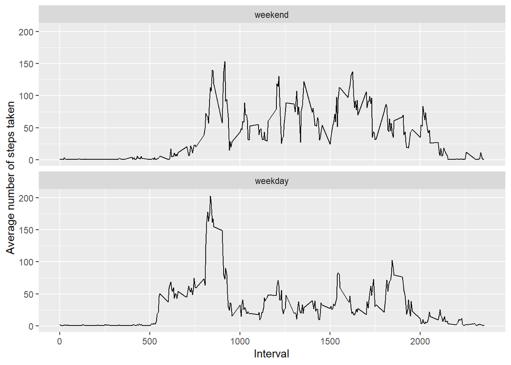

```r
library(ggplot2)
new_activity <- data.frame(data)
new_activity$steps[is.na(new_activity$steps)] <- mean_value

new_activity$date <- weekdays(as.Date(new_activity$date, "%Y-%m-%d"), abbreviate = TRUE)

weekdays1 <- c('pon', 'uto', 'sri', 'čet', 'pet')

new_activity$wDay <- factor(new_activity$date %in% weekdays1,
         levels=c(FALSE, TRUE), labels=c('weekend', 'weekday'))

new_activity <- new_activity %>%
  group_by(wDay, interval) %>%
  summarise(average = mean(steps))
qplot(interval, average, data = new_activity, facets = .~wDay, geom = "line",
      xlab = "Interval", ylab = "Average number of steps taken") + labs(colour = 'Type of day') + facet_wrap(facets = .~wDay, nrow = 2, ncol = 1)
```